# This is a note comparing method for RNAseq vs. Microarray

Jianying Li

17 October 2016

# 1 Introduction

# 2 Loading libraries and sources custom functions

```r
# Load packages
library(gplots)
library(ggplot2)
source ("X:/learningR/FancyScatterPlots/dmPairs.R")
source("x:/R-project/customPackages/plotTools.R")
source("x:/R-project/customPackages/dataManipTools.R")
```

# 3 Loading Microarray data

Affymetrix arrays were done at NIEHS genomic core and analyzed by Jianying Li. Details were documented at analysis.

Main steps are * Normalized by RMA * Filtered by pvac for non-informative probes * ANOVA model * Followed by Tukey’s contrast for comparison of interest * DEGs were extracted based on p-value and folde change

```r
glist_0_3 <- read.table ("X:/project2016/woychik-ma-rnaseq/DN-MA-analysis/glist.T0vsT3.noCUTOFF.csv", header = TRUE, sep=",")

glist_0_6 <- read.table ("X:/project2016/woychik-ma-rnaseq/DN-MA-analysis/glist.T0vsT6.noCUTOFF.csv", header = TRUE, sep=",")

glist_0_9 <- read.table ("X:/project2016/woychik-ma-rnaseq/DN-MA-analysis/glist.T0vsT9.noCUTOFF.csv", header = TRUE, sep=",")
```

# 4 Loading RNAseq results

##RNAseq results from Jianying

### 4.0.1 Working on day3 vs. day 0

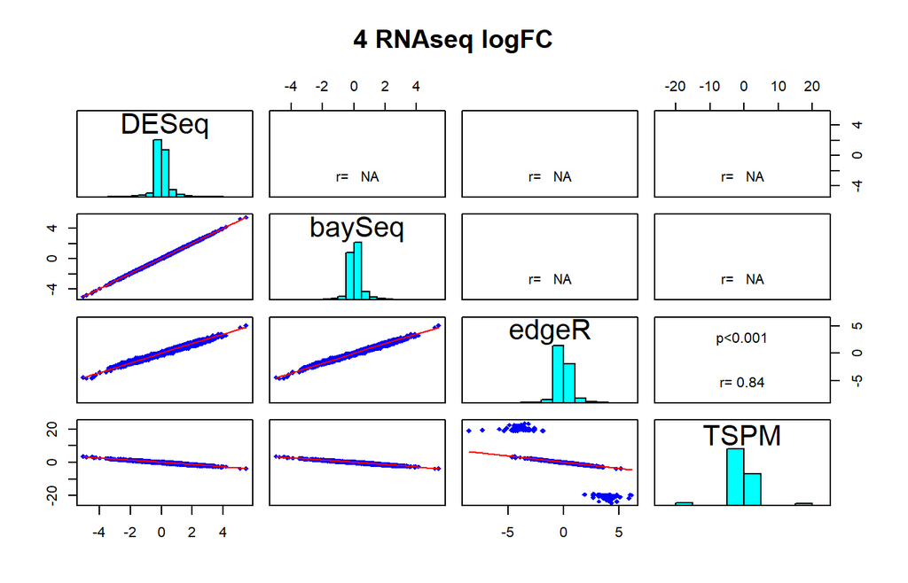

```r
## Three directories containing RNAseq
#setwd("X:/project2016/woychik-ma-rnaseq/RNAseqEnsemble/DN_Day_0_3/DE/R")
#setwd("X:/project2016/woychik-ma-rnaseq/RNAseqEnsemble/DN_Day_0_6/DE/R")
#setwd("X:/project2016/woychik-ma-rnaseq/RNAseqEnsemble/DN_Day_0_9/DE/R")

## Save DEG day3 vs. day0
dt <- read.csv("X:/project2016/woychik-ma-rnaseq/RNAseqEnsemble/DN_Day_0_3/DE/R/de_gene_expr_count.csv")
#head(dt)

dm <- cbind(dt$DESeq_log2FC,dt$baySeq_log2FC,dt$edgeR_log2FC,dt$TSPM_log2FC)
#dim(dm)
colnames(dm) <- c("DESeq", "baySeq", "edgeR", "TSPM")
pairs(dm, main = "4 RNAseq logFC", lower.panel=panel.smooth, upper.panel=panel.cor,diag.panel=panel.hist)
```

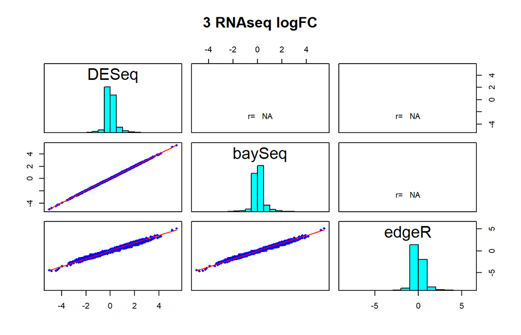

```r
##  Dropping TSPM

dm2 <- cbind(dt$DESeq_log2FC,dt$baySeq_log2FC,dt$edgeR_log2FC)
#dim(dm2)
colnames(dm2) <- c("DESeq", "baySeq", "edgeR")
pairs(dm2, main = "3 RNAseq logFC", lower.panel=panel.smooth, upper.panel=panel.cor,diag.panel=panel.hist)
```

```r
## Save DEG day3 vs. day0
rnaseq_day3_0_deg <- dt
```

### 4.0.2 Working on day6 vs. day 0

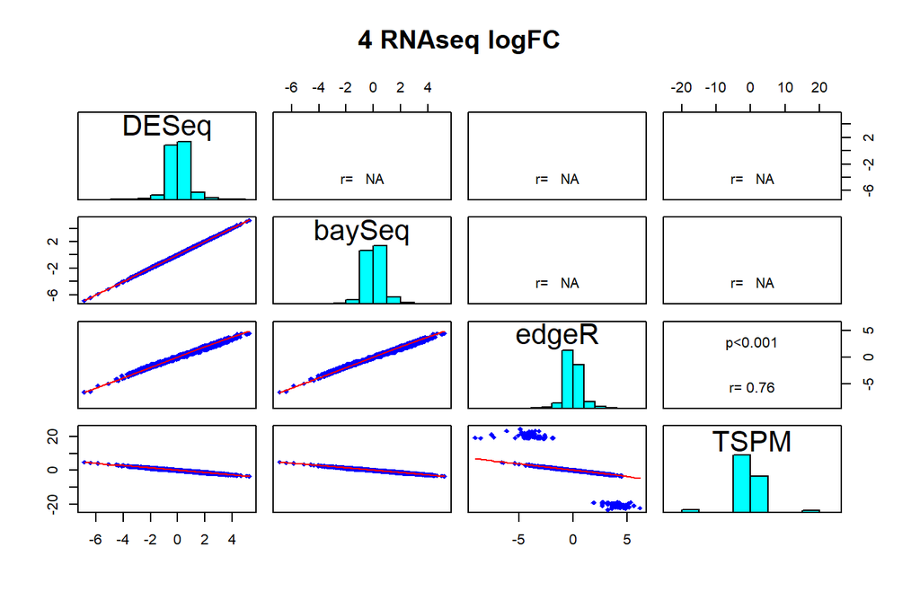

```r
dt <- read.csv("X:/project2016/woychik-ma-rnaseq/RNAseqEnsemble/DN_Day_0_6/DE/R/de_gene_expr_count.csv")
#head(dt)

dm <- cbind(dt$DESeq_log2FC,dt$baySeq_log2FC,dt$edgeR_log2FC,dt$TSPM_log2FC)
#dim(dm)
colnames(dm) <- c("DESeq", "baySeq", "edgeR", "TSPM")
pairs(dm, main = "4 RNAseq logFC", lower.panel=panel.smooth, upper.panel=panel.cor,diag.panel=panel.hist)
```

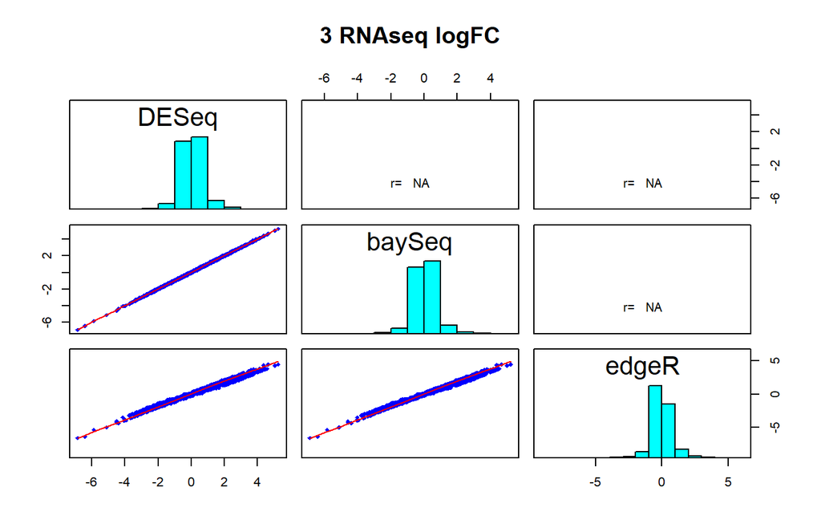

```r
##  Dropping TSPM

dm2 <- cbind(dt$DESeq_log2FC,dt$baySeq_log2FC,dt$edgeR_log2FC)
#dim(dm2)
colnames(dm2) <- c("DESeq", "baySeq", "edgeR")
pairs(dm2, main = "3 RNAseq logFC", lower.panel=panel.smooth, upper.panel=panel.cor,diag.panel=panel.hist)
```

```r
## Save DEG day3 vs. day0
rnaseq_day6_0_deg <- dt
```

### 4.0.3 Working on day9 vs. day 0

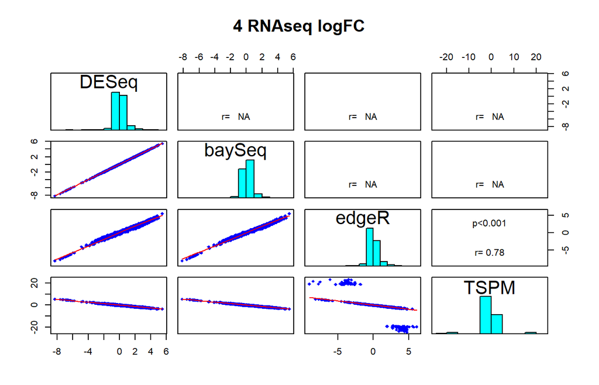

```r
dt <- read.csv("X:/project2016/woychik-ma-rnaseq/RNAseqEnsemble/DN_Day_0_9/DE/R/de_gene_expr_count.csv")
#head(dt)

dm <- cbind(dt$DESeq_log2FC,dt$baySeq_log2FC,dt$edgeR_log2FC,dt$TSPM_log2FC)
#dim(dm)
colnames(dm) <- c("DESeq", "baySeq", "edgeR", "TSPM")
pairs(dm, main = "4 RNAseq logFC", lower.panel=panel.smooth, upper.panel=panel.cor,diag.panel=panel.hist)
```

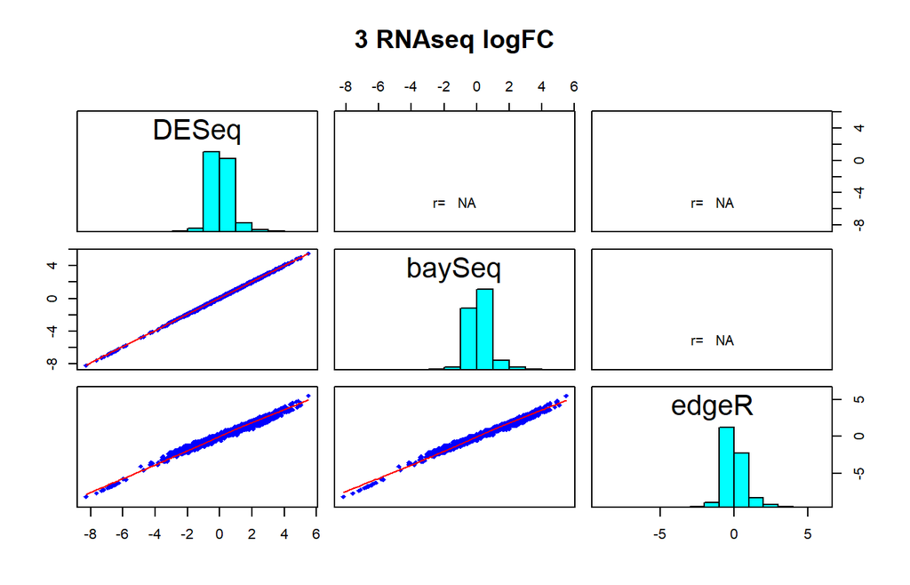

```r
##  Dropping TSPM

dm2 <- cbind(dt$DESeq_log2FC,dt$baySeq_log2FC,dt$edgeR_log2FC)
#dim(dm2)
colnames(dm2) <- c("DESeq", "baySeq", "edgeR")
pairs(dm2, main = "3 RNAseq logFC", lower.panel=panel.smooth, upper.panel=panel.cor,diag.panel=panel.hist)
```

```r
## Save DEG day3 vs. day0
rnaseq_day9_0_deg <- dt
```

##RNAseq results from Ozzy

```r
## Three directories containing RNAseq
dt <- read.csv("x:/project2016/woychik-ma-rnaseq/comparison/ozzy_new_deg_rnaseq_rpkm.csv")

length(dt$HGNC.Approved.symbol[which(dt$PValue.d3.d0 <= 0.05)])
```

```
## [1] 236
```

```r
length(dt$HGNC.Approved.symbol[which(dt$PValue.d6.d0 <= 0.05)])
```

```
## [1] 2138
```

```r
length(dt$HGNC.Approved.symbol[which(dt$PValue.d9.d0 <= 0.05)])
```

```
## [1] 1273
```

```r
rnaseq_ozzy <- dt
```

#Comparing count-based (Jianying) vs. rpkm (Ozzy)

We have tried count-based analysis (DESeq, edgeR, baySeq and TSPM), when we

- Got count from the alignment .bam files
- Fitted different models (depeneds on which package we used)
- Getting DEGs based on two-group comparison: etc. day3 vs. day0
- Each model rendered a list of DEG based on p-value or FDR and fold change

##Comparison based on statistical significance

```r
#dt$HGNC.Approved.symbol[which(dt$PValue.d3.d0 <= 0.05)]
#dt$HGNC.Approved.symbol[which(dt$PValue.d6.d0 <= 0.05)]
#dt$HGNC.Approved.symbol[which(dt$PValue.d9.d0 <= 0.05)]

##  Day3 vs. day0


length(as.vector(as.character(rnaseq_ozzy$HGNC.Approved.symbol[which(dt$PValue.d3.d0 <= 0.05)])))
```

```
## [1] 236
```

```r
#length(as.vector(as.character(rnaseq_day3_0_deg$ID)))
#colnames(rnaseq_day3_0_deg)
#rnaseq_day3_0_deg$ID[which(rnaseq_day3_0_deg$DESeq_pvalue <= 0.05 )]

# DESeq

length(as.vector(as.character(rnaseq_day3_0_deg$ID[which(rnaseq_day3_0_deg$DESeq_pvalue <= 0.05 )])))
```

```
## [1] 252
```

```r
length(intersect(as.vector(as.character(rnaseq_ozzy$HGNC.Approved.symbol[which(dt$PValue.d3.d0 <= 0.05)])) ,
          as.vector(as.character(rnaseq_day3_0_deg$ID[which(rnaseq_day3_0_deg$DESeq_pvalue <= 0.05 )]))))
```

```
## [1] 28
```

```r
# baySeq

length(as.vector(as.character(rnaseq_day3_0_deg$ID[which(rnaseq_day3_0_deg$baySeq_FDR <= 0.5 )])))
```

```
## [1] 11
```

```r
length(intersect(as.vector(as.character(rnaseq_ozzy$HGNC.Approved.symbol[which(dt$PValue.d3.d0 <= 0.05)])) ,
         as.vector(as.character(rnaseq_day3_0_deg$ID[which(rnaseq_day3_0_deg$baySeq_FDR <= 0.5 )]))))
```

```
## [1] 2
```

```r
# TSPM

length(as.vector(as.character(rnaseq_day3_0_deg$ID[which(rnaseq_day3_0_deg$TSPM_pvalue <= 0.05 )])))
```

```
## [1] 1227
```

```r
length(intersect(as.vector(as.character(rnaseq_ozzy$HGNC.Approved.symbol[which(dt$PValue.d3.d0 <= 0.05)])) ,
        as.vector(as.character(rnaseq_day3_0_deg$ID[which(rnaseq_day3_0_deg$TSPM_pvalue <= 0.05 )]))))
```

```
## [1] 92
```

```r
# edgeR

length(as.vector(as.character(rnaseq_day3_0_deg$ID[which(rnaseq_day3_0_deg$edgeR_pvalue <= 0.05 )])))
```

```
## [1] 419
```

```r
length(intersect(as.vector(as.character(rnaseq_ozzy$HGNC.Approved.symbol[which(dt$PValue.d3.d0 <= 0.05)])) ,
        as.vector(as.character(rnaseq_day3_0_deg$ID[which(rnaseq_day3_0_deg$edgeR_pvalue <= 0.05 )]))))
```

```
## [1] 56
```

##Comparison based on biological significance (fold change)

```r
# Since there was ONLY logFC produced by count-based analysis
# It is needed to convert it backt o fold change

covert.to.foldchange <- function (log2FC)
{
  FC.return <- c()
  for (i in 1:length(log2FC))
  {
    if (is.na(log2FC[i]) | is.infinite (log2FC[i]))
    {
      FC.return[i] <- "NA"
    }else if (log2FC[i] >=0)
      {
       FC.return[i] <- log2FC[i]**2
    }else{
      FC.return[i] <- -(1/(2**log2FC[i]))
    }
  }
  return (as.numeric(FC.return))
}


#rnaseq_day3_0_FC <- covert.to.foldchange(rnaseq_day3_0_deg$DESeq_log2FC)
#rnaseq_day6_0_FC <- covert.to.foldchange(rnaseq_day6_0_deg$DESeq_log2FC)
#rnaseq_day9_0_FC <- covert.to.foldchange(rnaseq_day9_0_deg$DESeq_log2FC)


#which(abs(rnaseq_ozzy$Fold.Change.d3.d0) > 2)
#length(abs(rnaseq_day3_0_FC [!is.na(as.numeric(rnaseq_day3_0_FC))]) > min(abs(rnaseq_ozzy$Fold.Change.d3.d0)))

#which(abs(rnaseq_day3_0_FC [!is.na(as.numeric(rnaseq_day3_0_FC))]) > 2)
#which(abs(rnaseq_day6_0_FC [!is.na(as.numeric(rnaseq_day6_0_FC))]) > 2)
#which(abs(rnaseq_day9_0_FC [!is.na(as.numeric(rnaseq_day9_0_FC))]) > 2)
```

### 4.0.4 Day3 vs. day0

```r
# DESeq

rnaseq_day3_0_FC <- covert.to.foldchange(rnaseq_day3_0_deg$DESeq_log2FC)

DESeq_day3_0_FC <- as.vector(as.character(rnaseq_day3_0_deg$ID[which(abs(rnaseq_day3_0_FC [!is.na(as.numeric(rnaseq_day3_0_FC))]) > 2)]))

print ("Here are the overlap: DESeq vs rpkm")
```

```
## [1] "Here are the overlap: DESeq vs rpkm"
```

```r
length(intersect(as.vector(as.character(rnaseq_ozzy$HGNC.Approved.symbol[ which(abs(rnaseq_ozzy$Fold.Change.d3.d0) > 1.1)])) ,
      as.vector(as.character(rnaseq_day3_0_deg$ID[which(abs(rnaseq_day3_0_FC [!is.na(as.numeric(rnaseq_day3_0_FC))]) > 2)]))))
```

```
## [1] 59
```

```r
# baySeq
rnaseq_day3_0_FC <- covert.to.foldchange(rnaseq_day3_0_deg$baySeq_log2FC)
baySeq_day3_0_FC <-as.vector(as.character(rnaseq_day3_0_deg$ID[which(abs(rnaseq_day3_0_FC [!is.na(as.numeric(rnaseq_day3_0_FC))]) > 2)]))

print ("Here are the overlap: baySeq vs rpkm")
```

```
## [1] "Here are the overlap: baySeq vs rpkm"
```

```r
length(intersect(as.vector(as.character(rnaseq_ozzy$HGNC.Approved.symbol[ which(abs(rnaseq_ozzy$Fold.Change.d3.d0) > 1.1)])) ,
      as.vector(as.character(rnaseq_day3_0_deg$ID[which(abs(rnaseq_day3_0_FC [!is.na(as.numeric(rnaseq_day3_0_FC))]) > 2)]))))
```

```
## [1] 56
```

```r
# edgeR

rnaseq_day3_0_FC <- covert.to.foldchange(rnaseq_day3_0_deg$edgeR_log2FC)
edgeR_day3_0_FC <- as.vector(as.character(rnaseq_day3_0_deg$ID[which(abs(rnaseq_day3_0_FC [!is.na(as.numeric(rnaseq_day3_0_FC))]) > 2)]))

print ("Here are the overlap: edgeR vs rpkm")
```

```
## [1] "Here are the overlap: edgeR vs rpkm"
```

```r
length(intersect(as.vector(as.character(rnaseq_ozzy$HGNC.Approved.symbol[ which(abs(rnaseq_ozzy$Fold.Change.d3.d0) > 1.1)])) ,
      as.vector(as.character(rnaseq_day3_0_deg$ID[which(abs(rnaseq_day3_0_FC [!is.na(as.numeric(rnaseq_day3_0_FC))]) > 2)]))))
```

```
## [1] 44
```

```r
# TSPM

rnaseq_day3_0_FC <- covert.to.foldchange(rnaseq_day3_0_deg$TSPM_log2FC)
TSPM_day3_0_FC <- as.vector(as.character(rnaseq_day3_0_deg$ID[which(abs(rnaseq_day3_0_FC [!is.na(as.numeric(rnaseq_day3_0_FC))]) > 2)]))


print ("Here are the overlap: TSPM vs rpkm")
```

```
## [1] "Here are the overlap: TSPM vs rpkm"
```

```r
length(intersect(as.vector(as.character(rnaseq_ozzy$HGNC.Approved.symbol[ which(abs(rnaseq_ozzy$Fold.Change.d3.d0) > 1.1)])) ,
      as.vector(as.character(rnaseq_day3_0_deg$ID[which(abs(rnaseq_day3_0_FC [!is.na(as.numeric(rnaseq_day3_0_FC))]) > 2)]))))
```

```
## [1] 40
```

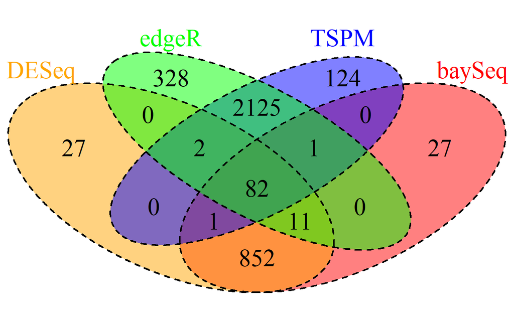

```r
VennDiagram <- draw.four.list.venndigram(
          DESeq_day3_0_FC ,
          baySeq_day3_0_FC ,
          edgeR_day3_0_FC,
          TSPM_day3_0_FC,
          "DESeq", "baySeq","edgeR","TSPM")
windows()
grid.draw(VennDiagram$figure)
```

### 4.0.5 Day6 vs. day0

```r
# DESeq

rnaseq_day6_0_FC <- covert.to.foldchange(rnaseq_day6_0_deg$DESeq_log2FC)
DESeq_day6_0_FC <- as.vector(as.character(rnaseq_day6_0_deg$ID[which(abs(rnaseq_day6_0_FC [!is.na(as.numeric(rnaseq_day6_0_FC))]) > 2)]))

print ("Here are the overlap: DESeq vs rpkm")
```

```
## [1] "Here are the overlap: DESeq vs rpkm"
```

```r
length(intersect(as.vector(as.character(rnaseq_ozzy$HGNC.Approved.symbol[ which(abs(rnaseq_ozzy$Fold.Change.d6.d0) > 1.1)])) ,
      as.vector(as.character(rnaseq_day6_0_deg$ID[which(abs(rnaseq_day6_0_FC [!is.na(as.numeric(rnaseq_day6_0_FC))]) > 2)]))))
```

```
## [1] 145
```

```r
# baySeq
rnaseq_day6_0_FC <- covert.to.foldchange(rnaseq_day6_0_deg$baySeq_log2FC)
baySeq_day6_0_FC <-as.vector(as.character(rnaseq_day6_0_deg$ID[which(abs(rnaseq_day6_0_FC [!is.na(as.numeric(rnaseq_day6_0_FC))]) > 2)]))

print ("Here are the overlap: baySeq vs rpkm")
```

```
## [1] "Here are the overlap: baySeq vs rpkm"
```

```r
length(intersect(as.vector(as.character(rnaseq_ozzy$HGNC.Approved.symbol[ which(abs(rnaseq_ozzy$Fold.Change.d6.d0) > 1.1)])) ,
      as.vector(as.character(rnaseq_day6_0_deg$ID[which(abs(rnaseq_day6_0_FC [!is.na(as.numeric(rnaseq_day6_0_FC))]) > 2)]))))
```

```
## [1] 144
```

```r
# edgeR

rnaseq_day6_0_FC <- covert.to.foldchange(rnaseq_day6_0_deg$edgeR_log2FC)
edgeR_day6_0_FC <- as.vector(as.character(rnaseq_day6_0_deg$ID[which(abs(rnaseq_day6_0_FC [!is.na(as.numeric(rnaseq_day6_0_FC))]) > 2)]))
print ("Here are the overlap: edgeR vs rpkm")
```

```
## [1] "Here are the overlap: edgeR vs rpkm"
```

```r
length(intersect(as.vector(as.character(rnaseq_ozzy$HGNC.Approved.symbol[ which(abs(rnaseq_ozzy$Fold.Change.d6.d0) > 1.1)])) ,
      as.vector(as.character(rnaseq_day6_0_deg$ID[which(abs(rnaseq_day6_0_FC [!is.na(as.numeric(rnaseq_day6_0_FC))]) > 2)]))))
```

```
## [1] 296
```

```r
# TSPM

rnaseq_day6_0_FC <- covert.to.foldchange(rnaseq_day6_0_deg$TSPM_log2FC)
TSPM_day6_0_FC <- as.vector(as.character(rnaseq_day6_0_deg$ID[which(abs(rnaseq_day6_0_FC [!is.na(as.numeric(rnaseq_day6_0_FC))]) > 2)]))

print ("Here are the overlap: TSPM vs rpkm")
```

```
## [1] "Here are the overlap: TSPM vs rpkm"
```

```r
length(intersect(as.vector(as.character(rnaseq_ozzy$HGNC.Approved.symbol[ which(abs(rnaseq_ozzy$Fold.Change.d6.d0) > 1.1)])) ,
      as.vector(as.character(rnaseq_day6_0_deg$ID[which(abs(rnaseq_day6_0_FC [!is.na(as.numeric(rnaseq_day6_0_FC))]) > 2)]))))
```

```
## [1] 189
```

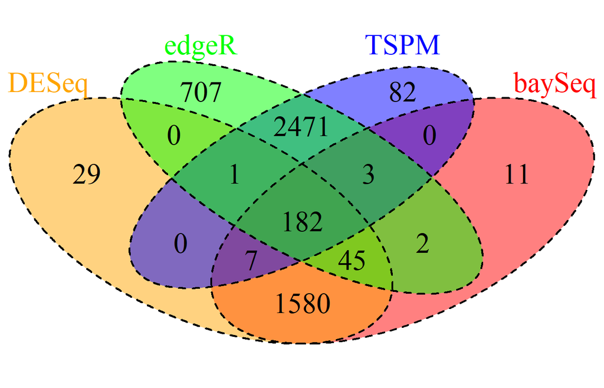

```r
VennDiagram <- draw.four.list.venndigram(
          DESeq_day6_0_FC ,
          baySeq_day6_0_FC ,
          edgeR_day6_0_FC,
          TSPM_day6_0_FC,
          "DESeq", "baySeq","edgeR","TSPM")
windows()
grid.draw(VennDiagram$figure)
```

### 4.0.6 Day9 vs. day0

```r
# DESeq

rnaseq_day9_0_FC <- covert.to.foldchange(rnaseq_day9_0_deg$DESeq_log2FC)
DESeq_day9_0_FC <- as.vector(as.character(rnaseq_day9_0_deg$ID[which(abs(rnaseq_day9_0_FC [!is.na(as.numeric(rnaseq_day9_0_FC))]) > 2)]))
print ("Here are the overlap: DESeq vs rpkm")
```

```
## [1] "Here are the overlap: DESeq vs rpkm"
```

```r
length(intersect(as.vector(as.character(rnaseq_ozzy$HGNC.Approved.symbol[ which(abs(rnaseq_ozzy$Fold.Change.d9.d0) > 1.1)])) ,
      as.vector(as.character(rnaseq_day9_0_deg$ID[which(abs(rnaseq_day9_0_FC [!is.na(as.numeric(rnaseq_day9_0_FC))]) > 2)]))))
```

```
## [1] 101
```

```r
# baySeq
rnaseq_day9_0_FC <- covert.to.foldchange(rnaseq_day9_0_deg$baySeq_log2FC)
baySeq_day9_0_FC <-as.vector(as.character(rnaseq_day9_0_deg$ID[which(abs(rnaseq_day9_0_FC [!is.na(as.numeric(rnaseq_day9_0_FC))]) > 2)]))



print ("Here are the overlap: baySeq vs rpkm")
```

```
## [1] "Here are the overlap: baySeq vs rpkm"
```

```r
length(intersect(as.vector(as.character(rnaseq_ozzy$HGNC.Approved.symbol[ which(abs(rnaseq_ozzy$Fold.Change.d9.d0) > 1.1)])) ,
      as.vector(as.character(rnaseq_day9_0_deg$ID[which(abs(rnaseq_day9_0_FC [!is.na(as.numeric(rnaseq_day9_0_FC))]) > 2)]))))
```

```
## [1] 103
```

```r
# edgeR

rnaseq_day9_0_FC <- covert.to.foldchange(rnaseq_day9_0_deg$edgeR_log2FC)
edgeR_day9_0_FC <- as.vector(as.character(rnaseq_day9_0_deg$ID[which(abs(rnaseq_day9_0_FC [!is.na(as.numeric(rnaseq_day9_0_FC))]) > 2)]))


print ("Here are the overlap: edgeR vs rpkm")
```

```
## [1] "Here are the overlap: edgeR vs rpkm"
```

```r
length(intersect(as.vector(as.character(rnaseq_ozzy$HGNC.Approved.symbol[ which(abs(rnaseq_ozzy$Fold.Change.d9.d0) > 1.1)])) ,
      as.vector(as.character(rnaseq_day9_0_deg$ID[which(abs(rnaseq_day9_0_FC [!is.na(as.numeric(rnaseq_day9_0_FC))]) > 2)]))))
```

```
## [1] 167
```

```r
# TSPM

rnaseq_day9_0_FC <- covert.to.foldchange(rnaseq_day9_0_deg$TSPM_log2FC)
TSPM_day9_0_FC <- as.vector(as.character(rnaseq_day9_0_deg$ID[which(abs(rnaseq_day9_0_FC [!is.na(as.numeric(rnaseq_day9_0_FC))]) > 2)]))

print ("Here are the overlap: TSPM vs rpkm")
```

```
## [1] "Here are the overlap: TSPM vs rpkm"
```

```r
length(intersect(as.vector(as.character(rnaseq_ozzy$HGNC.Approved.symbol[ which(abs(rnaseq_ozzy$Fold.Change.d9.d0) > 1.1)])) ,
      as.vector(as.character(rnaseq_day9_0_deg$ID[which(abs(rnaseq_day9_0_FC [!is.na(as.numeric(rnaseq_day9_0_FC))]) > 2)]))))
```

```
## [1] 147
```

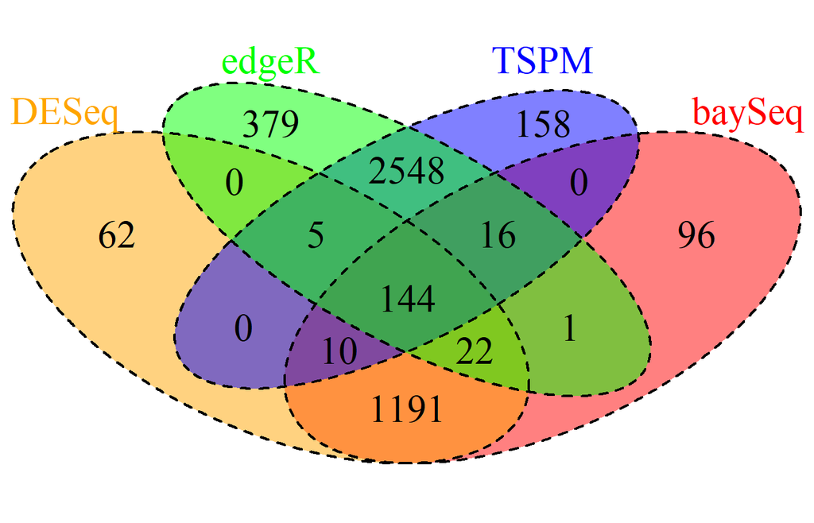

```r
VennDiagram <- draw.four.list.venndigram(
          DESeq_day9_0_FC ,
          baySeq_day9_0_FC ,
          edgeR_day9_0_FC,
          TSPM_day9_0_FC,
          "DESeq", "baySeq","edgeR","TSPM")
windows()
grid.draw(VennDiagram$figure)
```

#Comparing between two RNAseq methods: count-based & rpkm vs. microarray

## 4.1 Day3 vs day0

```r
str(glist_0_3)
```

```
## 'data.frame':    16722 obs. of  7 variables:
##  $ X          : Factor w/ 16722 levels "1053_at","1316_at",..: 8425 6277 5785 14453 4121 13989 10580 5786 14270 14324 ...
##  $ P.Value    : num  1.96e-07 8.78e-04 1.63e-03 3.37e-03 4.23e-03 ...
##  $ adj.P.Val  : num  0.00367 0.99995 0.99995 0.99995 0.99995 ...
##  $ Fold.T0vsT3: num  -8.58 -3.43 2.25 -1.73 -2.04 ...
##  $ up.down    : int  -1 -1 1 -1 -1 1 1 1 1 1 ...
##  $ symbol     : Factor w/ 9802 levels "A1BG","A2M-AS1",..: 6196 4601 4494 2695 564 1633 778 4494 7790 4521 ...
##  $ description: Factor w/ 9802 levels "1-acylglycerol-3-phosphate O-acyltransferase 1",..: 5976 4845 4191 2733 573 1009 780 4191 7337 4336 ...
```

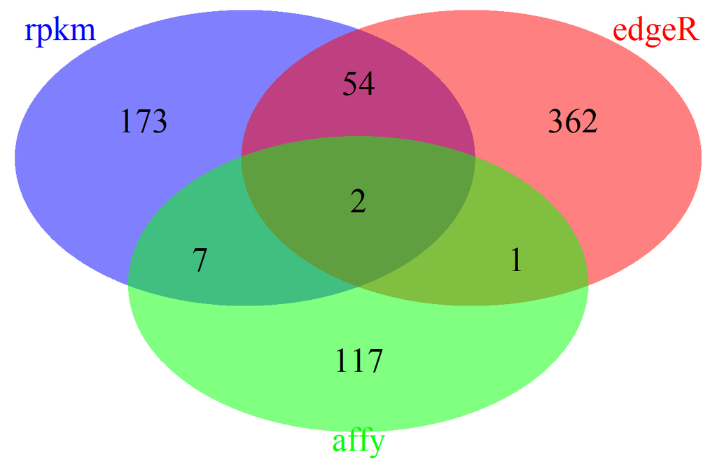

```r
# edgeR

VennDiagram <- draw.three.list.venndigram(
        as.vector(as.character(rnaseq_ozzy$HGNC.Approved.symbol[which(dt$PValue.d3.d0 <= 0.05)])) ,
        as.vector(as.character(rnaseq_day3_0_deg$ID[which(rnaseq_day3_0_deg$edgeR_pvalue <= 0.05 )])),
        as.vector(as.character(glist_0_3$symbol[which(glist_0_3$P.Value<=0.05)])),
        "rpkm", "edgeR","affy")
grid.draw(VennDiagram$figure)
```

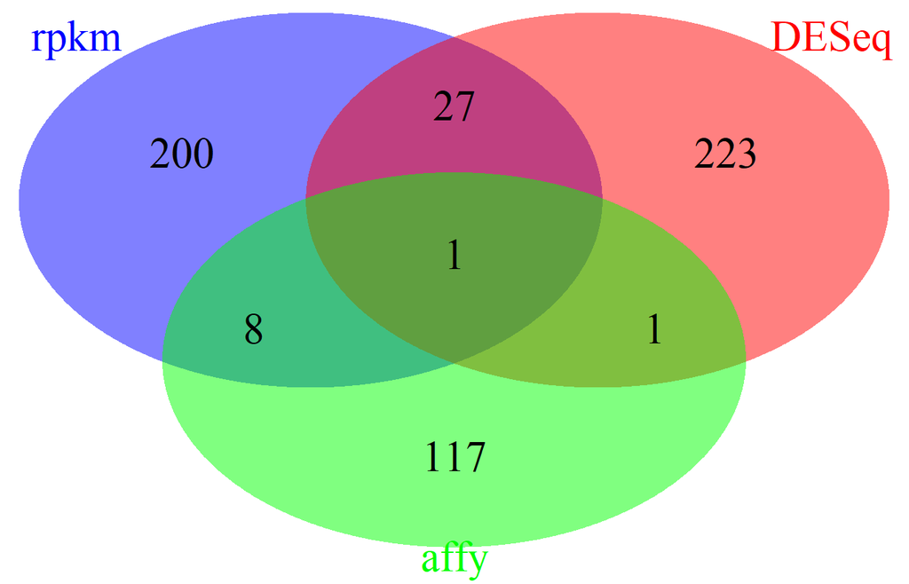

```r
windows()
# DESeq

VennDiagram <- draw.three.list.venndigram(
          as.vector(as.character(rnaseq_ozzy$HGNC.Approved.symbol[which(dt$PValue.d3.d0 <= 0.05)])) ,
          as.vector(as.character(rnaseq_day3_0_deg$ID[which(rnaseq_day3_0_deg$DESeq_pvalue <= 0.05 )])),
          as.vector(as.character(glist_0_3$symbol[which(glist_0_3$P.Value<=0.05)])),
          "rpkm", "DESeq","affy")
grid.draw(VennDiagram$figure)
```

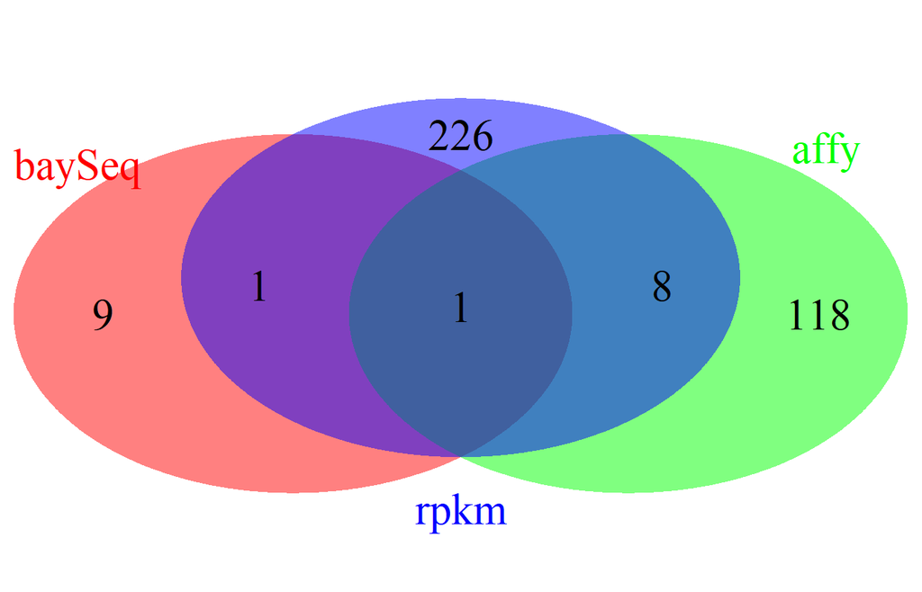

```r
windows()
# baySeq


VennDiagram <- draw.three.list.venndigram(
          as.vector(as.character(rnaseq_ozzy$HGNC.Approved.symbol[which(dt$PValue.d3.d0 <= 0.05)])) ,
          as.vector(as.character(rnaseq_day3_0_deg$ID[which(rnaseq_day3_0_deg$baySeq_FDR <= 0.5)])),
          as.vector(as.character(glist_0_3$symbol[which(glist_0_3$P.Value<=0.05)])),
          "rpkm", "baySeq","affy")
grid.draw(VennDiagram$figure)
```

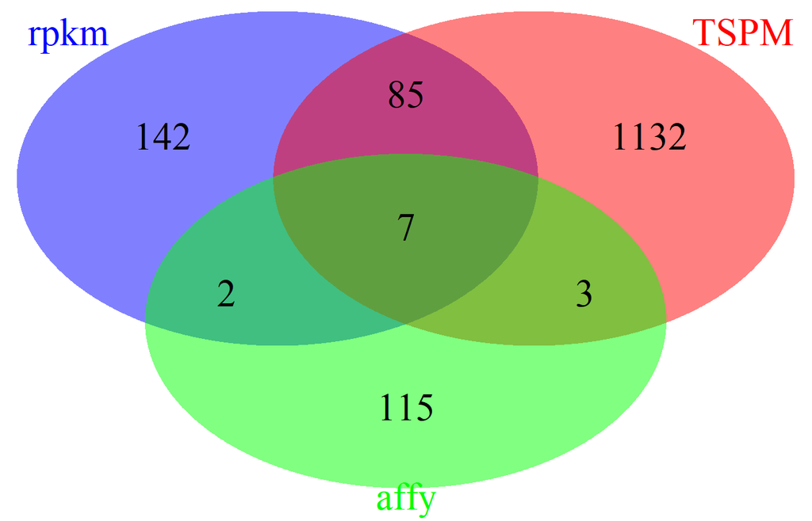

```r
windows()
# TSPM

VennDiagram <- draw.three.list.venndigram(
          as.vector(as.character(rnaseq_ozzy$HGNC.Approved.symbol[which(dt$PValue.d3.d0 <= 0.05)])) ,
          as.vector(as.character(rnaseq_day3_0_deg$ID[which(rnaseq_day3_0_deg$TSPM_pvalue <= 0.05)])),
          as.vector(as.character(glist_0_3$symbol[which(glist_0_3$P.Value<=0.05)])),
          "rpkm", "TSPM","affy")
grid.draw(VennDiagram$figure)
```

## 4.2 Day6vs day0

```r
str(glist_0_6)
```

```
## 'data.frame':    16722 obs. of  7 variables:
##  $ X          : Factor w/ 16722 levels "1053_at","1316_at",..: 8425 6965 14736 15719 5986 6277 141 140 14324 8239 ...
##  $ P.Value    : num  1.17e-07 1.36e-06 2.47e-06 4.83e-06 1.30e-05 ...
##  $ adj.P.Val  : num  0.0022 0.00963 0.01158 0.01811 0.0306 ...
##  $ Fold.T0vsT6: num  -9.46 4.16 3.54 -5.97 -2.72 ...
##  $ up.down    : int  -1 1 1 -1 -1 -1 1 1 1 -1 ...
##  $ symbol     : Factor w/ 9802 levels "A1BG","A2M-AS1",..: 6196 9389 4379 2395 6280 4601 1730 1730 4521 6131 ...
##  $ description: Factor w/ 9802 levels "1-acylglycerol-3-phosphate O-acyltransferase 1",..: 5976 9726 9002 2563 6359 4845 1903 1903 4336 5897 ...
```

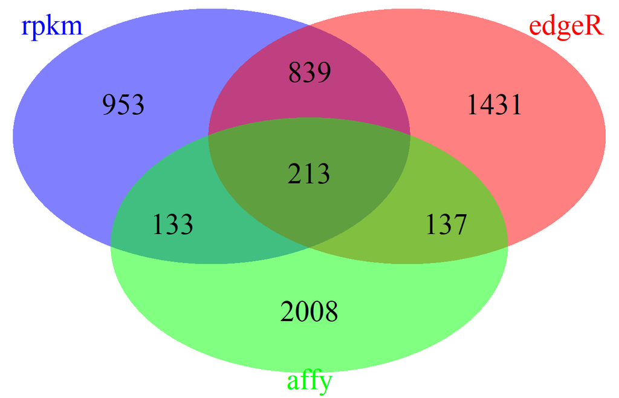

```r
windows()
# edgeR

VennDiagram <- draw.three.list.venndigram(
        as.vector(as.character(rnaseq_ozzy$HGNC.Approved.symbol[which(dt$PValue.d6.d0 <= 0.05)])) ,
        as.vector(as.character(rnaseq_day3_0_deg$ID[which(rnaseq_day6_0_deg$edgeR_pvalue <= 0.05 )])),
        as.vector(as.character(glist_0_6$symbol[which(glist_0_6$P.Value<=0.05)])),
        "rpkm", "edgeR","affy")
grid.draw(VennDiagram$figure)
```

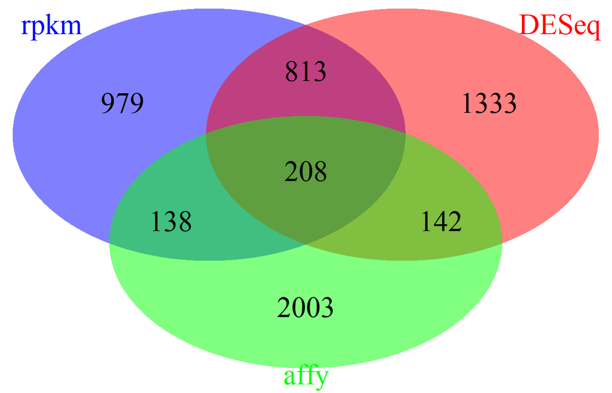

```r
windows()
# DESeq

VennDiagram <- draw.three.list.venndigram(
          as.vector(as.character(rnaseq_ozzy$HGNC.Approved.symbol[which(dt$PValue.d6.d0 <= 0.05)])) ,
          as.vector(as.character(rnaseq_day6_0_deg$ID[which(rnaseq_day6_0_deg$DESeq_pvalue <= 0.05 )])),
          as.vector(as.character(glist_0_6$symbol[which(glist_0_6$P.Value<=0.05)])),
          "rpkm", "DESeq","affy")
grid.draw(VennDiagram$figure)
```

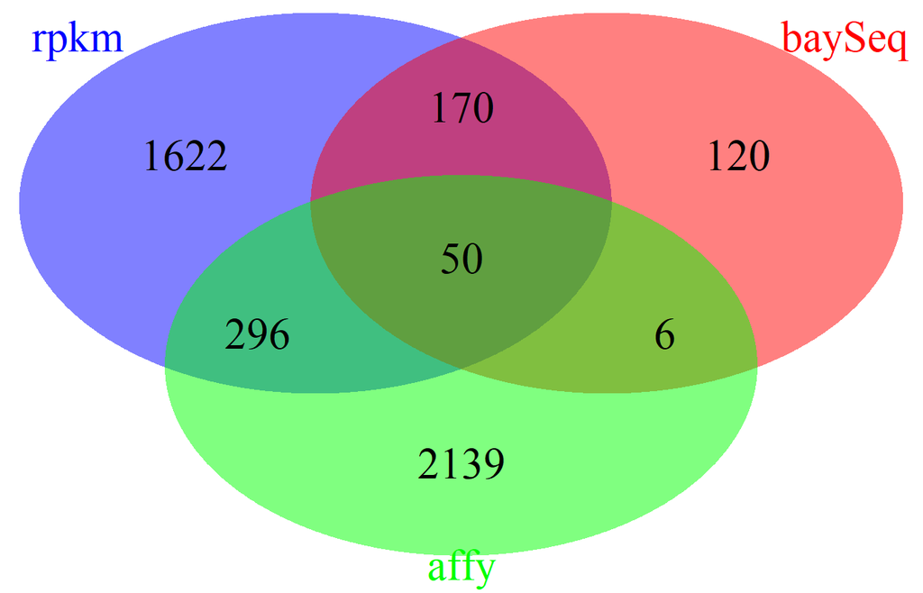

```r
windows()
# baySeq


VennDiagram <- draw.three.list.venndigram(
          as.vector(as.character(rnaseq_ozzy$HGNC.Approved.symbol[which(dt$PValue.d6.d0 <= 0.05)])) ,
          as.vector(as.character(rnaseq_day6_0_deg$ID[which(rnaseq_day6_0_deg$baySeq_FDR <= 0.5)])),
          as.vector(as.character(glist_0_6$symbol[which(glist_0_6$P.Value<=0.05)])),
          "rpkm", "baySeq","affy")
grid.draw(VennDiagram$figure)
```

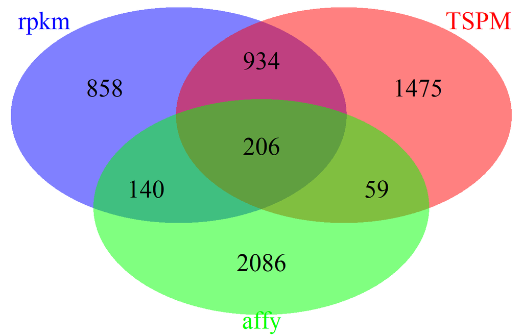

```r
windows()

# TSPM

VennDiagram <- draw.three.list.venndigram(
          as.vector(as.character(rnaseq_ozzy$HGNC.Approved.symbol[which(dt$PValue.d6.d0 <= 0.05)])) ,
          as.vector(as.character(rnaseq_day6_0_deg$ID[which(rnaseq_day6_0_deg$TSPM_pvalue <= 0.05)])),
          as.vector(as.character(glist_0_6$symbol[which(glist_0_6$P.Value<=0.05)])),
          "rpkm", "TSPM","affy")
grid.draw(VennDiagram$figure)
```

## 4.3 Day9 vs day0

```r
str(glist_0_9)
```

```
## 'data.frame':    16722 obs. of  7 variables:
##  $ X          : Factor w/ 16722 levels "1053_at","1316_at",..: 9586 539 16389 140 141 7198 12338 14736 576 7059 ...
##  $ P.Value    : num  3.66e-08 4.14e-08 5.09e-08 6.39e-08 6.84e-08 ...
##  $ adj.P.Val  : num  0.00021 0.00021 0.00021 0.00021 0.00021 ...
##  $ Fold.T0vsT9: num  8.38 -9.35 -9.86 4.3 4.41 ...
##  $ up.down    : int  1 -1 -1 1 1 1 1 1 -1 1 ...
##  $ symbol     : Factor w/ 9802 levels "A1BG","A2M-AS1",..: 9102 1264 7983 1730 1730 2868 3384 4379 9125 6761 ...
##  $ description: Factor w/ 9802 levels "1-acylglycerol-3-phosphate O-acyltransferase 1",..: 9145 1845 7192 1903 1903 2697 3153 9002 9165 6721 ...
```

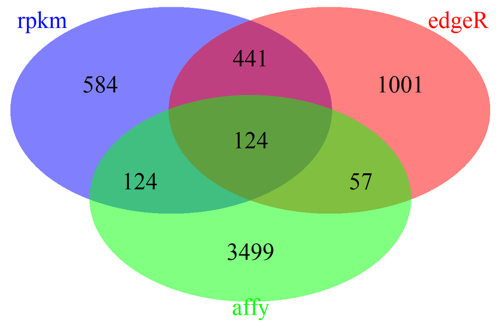

```r
# edgeR
windows()
VennDiagram <- draw.three.list.venndigram(
        as.vector(as.character(rnaseq_ozzy$HGNC.Approved.symbol[which(dt$PValue.d9.d0 <= 0.05)])) ,
        as.vector(as.character(rnaseq_day9_0_deg$ID[which(rnaseq_day9_0_deg$edgeR_pvalue <= 0.05 )])),
        as.vector(as.character(glist_0_9$symbol[which(glist_0_9$P.Value<=0.05)])),
        "rpkm", "edgeR","affy")
grid.draw(VennDiagram$figure)
```

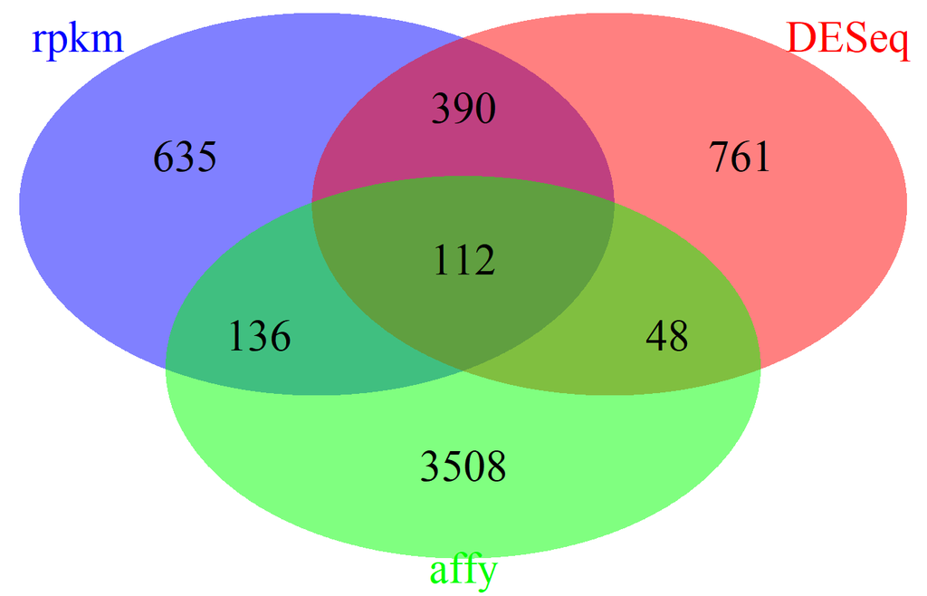

```r
windows()
# DESeq

VennDiagram <- draw.three.list.venndigram(
          as.vector(as.character(rnaseq_ozzy$HGNC.Approved.symbol[which(dt$PValue.d9.d0 <= 0.05)])) ,
          as.vector(as.character(rnaseq_day9_0_deg$ID[which(rnaseq_day9_0_deg$DESeq_pvalue <= 0.05 )])),
          as.vector(as.character(glist_0_9$symbol[which(glist_0_9$P.Value<=0.05)])),
          "rpkm", "DESeq","affy")
grid.draw(VennDiagram$figure)
```

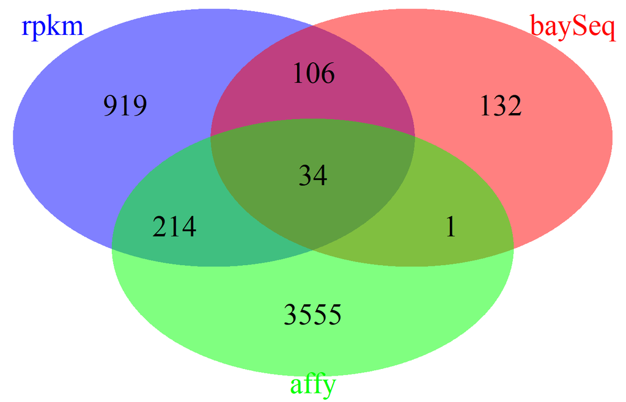

```r
windows()
# baySeq


VennDiagram <- draw.three.list.venndigram(
          as.vector(as.character(rnaseq_ozzy$HGNC.Approved.symbol[which(dt$PValue.d9.d0 <= 0.05)])) ,
          as.vector(as.character(rnaseq_day9_0_deg$ID[which(rnaseq_day9_0_deg$baySeq_FDR <= 0.5)])),
          as.vector(as.character(glist_0_9$symbol[which(glist_0_9$P.Value<=0.05)])),
          "rpkm", "baySeq","affy")
grid.draw(VennDiagram$figure)
```

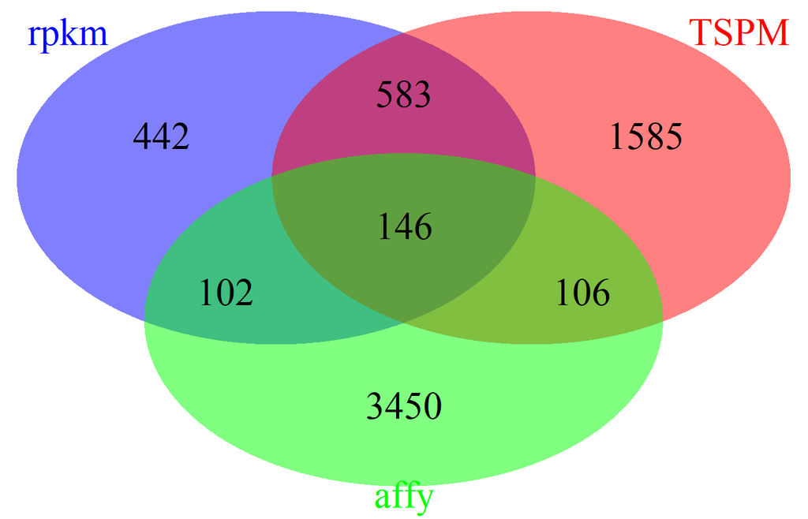

```r
windows()
# TSPM

VennDiagram <- draw.three.list.venndigram(
          as.vector(as.character(rnaseq_ozzy$HGNC.Approved.symbol[which(dt$PValue.d9.d0 <= 0.05)])) ,
          as.vector(as.character(rnaseq_day9_0_deg$ID[which(rnaseq_day9_0_deg$TSPM_pvalue <= 0.05)])),
          as.vector(as.character(glist_0_9$symbol[which(glist_0_9$P.Value<=0.05)])),
          "rpkm", "TSPM","affy")
grid.draw(VennDiagram$figure)
```

##Comparison based on biological significance (fold change)

```r
# Since there was ONLY logFC produced by count-based analysis
# It is needed to convert it backt o fold change

covert.to.foldchange <- function (log2FC)
{
  FC.return <- c()
  for (i in 1:length(log2FC))
  {
    if (is.na(log2FC[i]) | is.infinite (log2FC[i]))
    {
      FC.return[i] <- "NA"
    }else if (log2FC[i] >=0)
      {
       FC.return[i] <- log2FC[i]**2
    }else{
      FC.return[i] <- -(1/(2**log2FC[i]))
    }
  }
  return (as.numeric(FC.return))
}


#rnaseq_day3_0_FC <- covert.to.foldchange(rnaseq_day3_0_deg$DESeq_log2FC)
#rnaseq_day6_0_FC <- covert.to.foldchange(rnaseq_day6_0_deg$DESeq_log2FC)
#rnaseq_day9_0_FC <- covert.to.foldchange(rnaseq_day9_0_deg$DESeq_log2FC)


#which(abs(rnaseq_ozzy$Fold.Change.d3.d0) > 2)
#length(abs(rnaseq_day3_0_FC [!is.na(as.numeric(rnaseq_day3_0_FC))]) > min(abs(rnaseq_ozzy$Fold.Change.d3.d0)))

#which(abs(rnaseq_day3_0_FC [!is.na(as.numeric(rnaseq_day3_0_FC))]) > 2)
#which(abs(rnaseq_day6_0_FC [!is.na(as.numeric(rnaseq_day6_0_FC))]) > 2)
#which(abs(rnaseq_day9_0_FC [!is.na(as.numeric(rnaseq_day9_0_FC))]) > 2)
```

### 4.3.1 Day3 vs. day0

```r
# DESeq

rnaseq_day3_0_FC <- covert.to.foldchange(rnaseq_day3_0_deg$DESeq_log2FC)

length(intersect(as.vector(as.character(rnaseq_ozzy$HGNC.Approved.symbol[ which(abs(rnaseq_ozzy$Fold.Change.d3.d0) > 1.1)])) ,
      as.vector(as.character(rnaseq_day3_0_deg$ID[which(abs(rnaseq_day3_0_FC [!is.na(as.numeric(rnaseq_day3_0_FC))]) > 2)]))))
```

```
## [1] 59
```

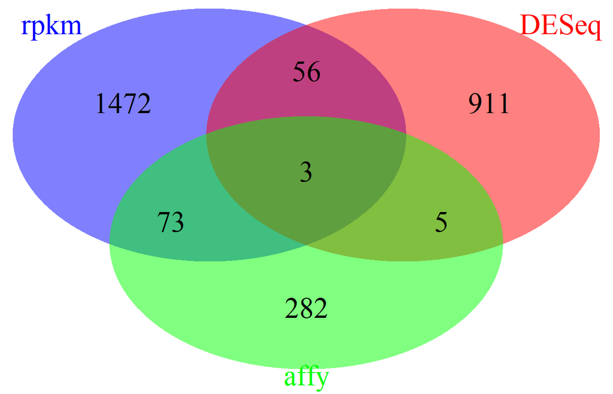

```r
VennDiagram <- draw.three.list.venndigram(
        as.vector(as.character(rnaseq_ozzy$HGNC.Approved.symbol[ which(abs(rnaseq_ozzy$Fold.Change.d3.d0) > 1.1)]))  ,
        as.vector(as.character(rnaseq_day3_0_deg$ID[which(abs(rnaseq_day3_0_FC [!is.na(as.numeric(rnaseq_day3_0_FC))]) > 2)])),
        as.vector(as.character(glist_0_3$symbol[which(abs(glist_0_3$Fold.T0vsT3) > 1.5)])),
        "rpkm", "DESeq","affy")
windows()
grid.draw(VennDiagram$figure)
```

```r
# baySeq
rnaseq_day3_0_FC <- covert.to.foldchange(rnaseq_day3_0_deg$baySeq_log2FC)

length(intersect(as.vector(as.character(rnaseq_ozzy$HGNC.Approved.symbol[ which(abs(rnaseq_ozzy$Fold.Change.d3.d0) > 1.1)])) ,
      as.vector(as.character(rnaseq_day3_0_deg$ID[which(abs(rnaseq_day3_0_FC [!is.na(as.numeric(rnaseq_day3_0_FC))]) > 2)]))))
```

```
## [1] 56
```

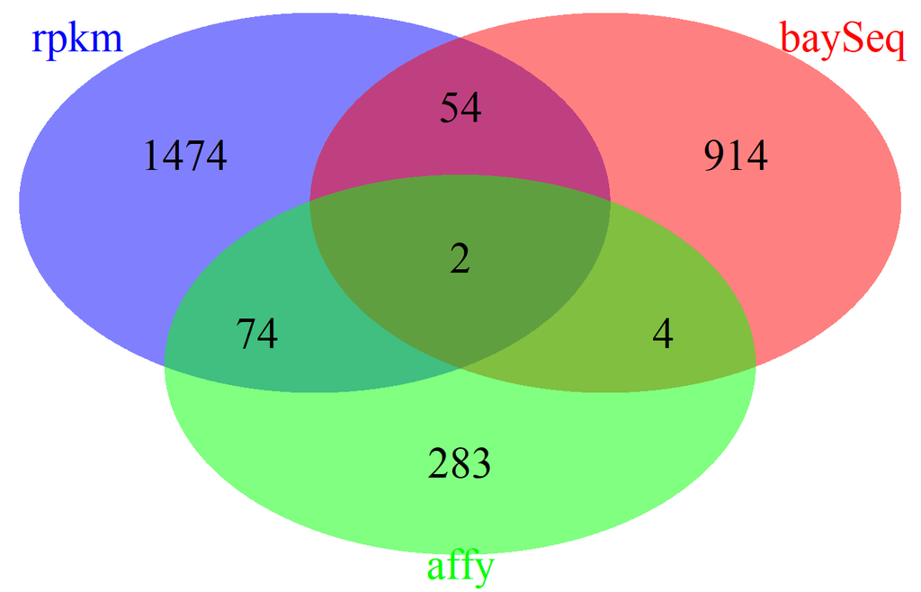

```r
VennDiagram <- draw.three.list.venndigram(
        as.vector(as.character(rnaseq_ozzy$HGNC.Approved.symbol[ which(abs(rnaseq_ozzy$Fold.Change.d3.d0) > 1.1)]))  ,
        as.vector(as.character(rnaseq_day3_0_deg$ID[which(abs(rnaseq_day3_0_FC [!is.na(as.numeric(rnaseq_day3_0_FC))]) > 2)])),
        as.vector(as.character(glist_0_3$symbol[which(abs(glist_0_3$Fold.T0vsT3) > 1.5)])),
        "rpkm", "baySeq","affy")
windows()
grid.draw(VennDiagram$figure)
```

```r
# edgeR

rnaseq_day3_0_FC <- covert.to.foldchange(rnaseq_day3_0_deg$edgeR_log2FC)

length(intersect(as.vector(as.character(rnaseq_ozzy$HGNC.Approved.symbol[ which(abs(rnaseq_ozzy$Fold.Change.d3.d0) > 1.1)])) ,
      as.vector(as.character(rnaseq_day3_0_deg$ID[which(abs(rnaseq_day3_0_FC [!is.na(as.numeric(rnaseq_day3_0_FC))]) > 2)]))))
```

```
## [1] 44
```

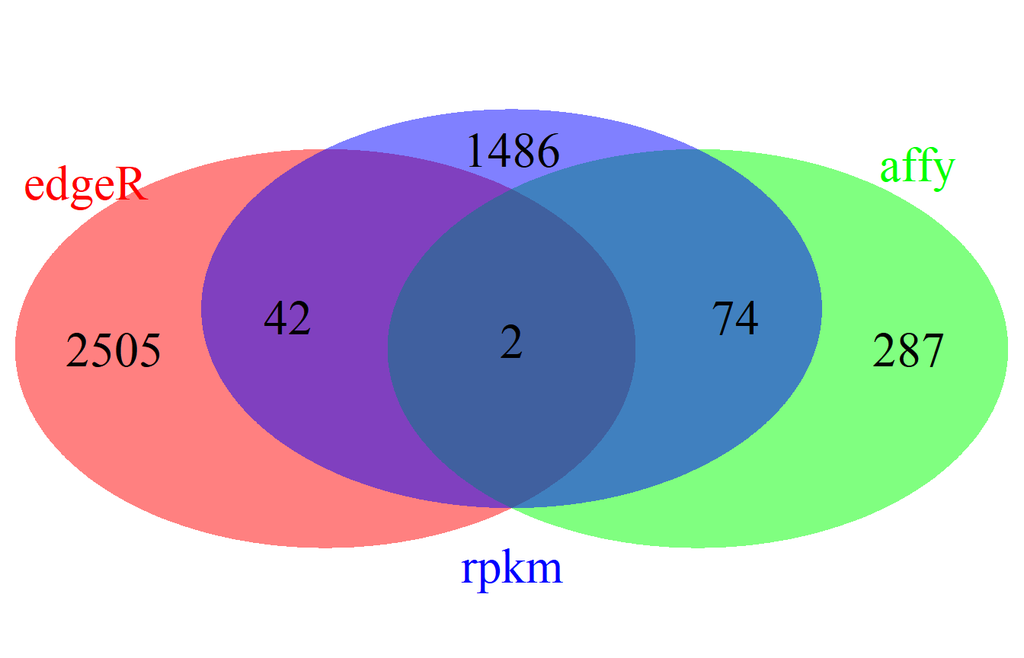

```r
VennDiagram <- draw.three.list.venndigram(
        as.vector(as.character(rnaseq_ozzy$HGNC.Approved.symbol[ which(abs(rnaseq_ozzy$Fold.Change.d3.d0) > 1.1)]))  ,
        as.vector(as.character(rnaseq_day3_0_deg$ID[which(abs(rnaseq_day3_0_FC [!is.na(as.numeric(rnaseq_day3_0_FC))]) > 2)])),
        as.vector(as.character(glist_0_3$symbol[which(abs(glist_0_3$Fold.T0vsT3) > 1.5)])),
        "rpkm", "edgeR","affy")
windows()
grid.draw(VennDiagram$figure)
```

```r
# TSPM

rnaseq_day3_0_FC <- covert.to.foldchange(rnaseq_day3_0_deg$TSPM_log2FC)

length(intersect(as.vector(as.character(rnaseq_ozzy$HGNC.Approved.symbol[ which(abs(rnaseq_ozzy$Fold.Change.d3.d0) > 1.1)])) ,
      as.vector(as.character(rnaseq_day3_0_deg$ID[which(abs(rnaseq_day3_0_FC [!is.na(as.numeric(rnaseq_day3_0_FC))]) > 2)]))))
```

```
## [1] 40
```

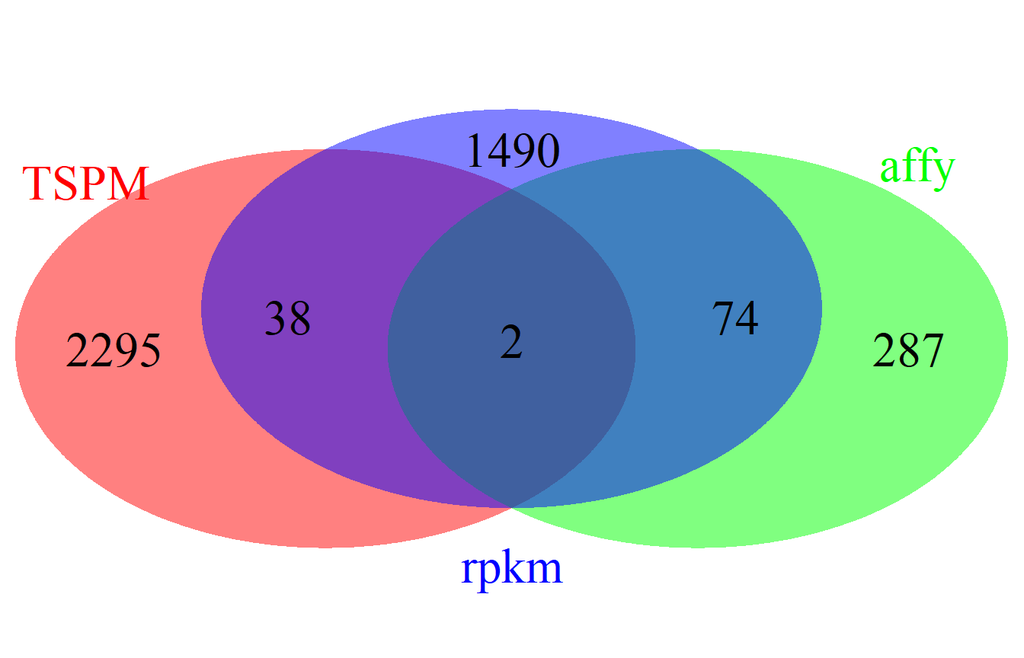

```r
VennDiagram <- draw.three.list.venndigram(
        as.vector(as.character(rnaseq_ozzy$HGNC.Approved.symbol[ which(abs(rnaseq_ozzy$Fold.Change.d3.d0) > 1.1)]))  ,
        as.vector(as.character(rnaseq_day3_0_deg$ID[which(abs(rnaseq_day3_0_FC [!is.na(as.numeric(rnaseq_day3_0_FC))]) > 2)])),
        as.vector(as.character(glist_0_3$symbol[which(abs(glist_0_3$Fold.T0vsT3) > 1.5)])),
        "rpkm", "TSPM","affy")
windows()
grid.draw(VennDiagram$figure)
```

### 4.3.2 Day6 vs. day0

```r
# DESeq

rnaseq_day6_0_FC <- covert.to.foldchange(rnaseq_day6_0_deg$DESeq_log2FC)

length(intersect(as.vector(as.character(rnaseq_ozzy$HGNC.Approved.symbol[ which(abs(rnaseq_ozzy$Fold.Change.d6.d0) > 1.1)])) ,
      as.vector(as.character(rnaseq_day6_0_deg$ID[which(abs(rnaseq_day6_0_FC [!is.na(as.numeric(rnaseq_day6_0_FC))]) > 2)]))))
```

```
## [1] 145
```

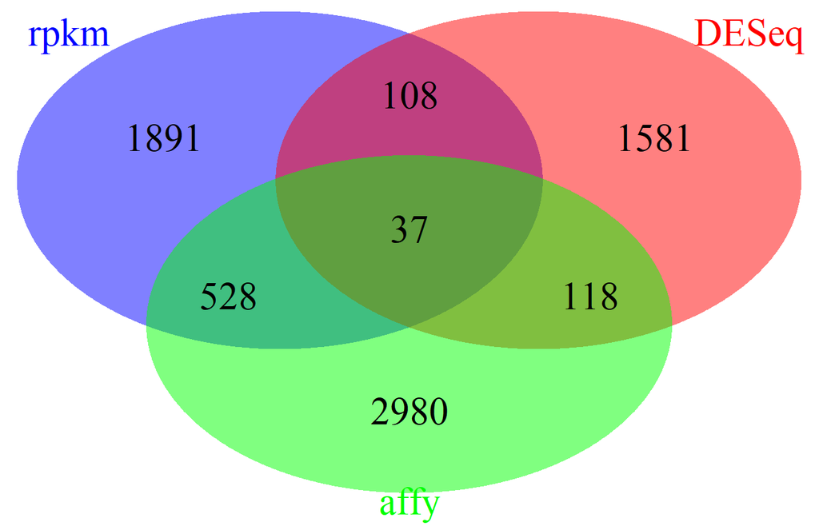

```r
VennDiagram <- draw.three.list.venndigram(
        as.vector(as.character(rnaseq_ozzy$HGNC.Approved.symbol[ which(abs(rnaseq_ozzy$Fold.Change.d6.d0) > 1.1)]))  ,
        as.vector(as.character(rnaseq_day6_0_deg$ID[which(abs(rnaseq_day6_0_FC [!is.na(as.numeric(rnaseq_day6_0_FC))]) > 2)])),
        as.vector(as.character(glist_0_6$symbol[which(abs(glist_0_6$Fold.T0vsT6) > 1.5)])),
        "rpkm", "DESeq","affy")
windows()
grid.draw(VennDiagram$figure)
```

```r
# baySeq
rnaseq_day6_0_FC <- covert.to.foldchange(rnaseq_day6_0_deg$baySeq_log2FC)

length(intersect(as.vector(as.character(rnaseq_ozzy$HGNC.Approved.symbol[ which(abs(rnaseq_ozzy$Fold.Change.d6.d0) > 1.1)])) ,
      as.vector(as.character(rnaseq_day6_0_deg$ID[which(abs(rnaseq_day6_0_FC [!is.na(as.numeric(rnaseq_day6_0_FC))]) > 2)]))))
```

```
## [1] 144
```

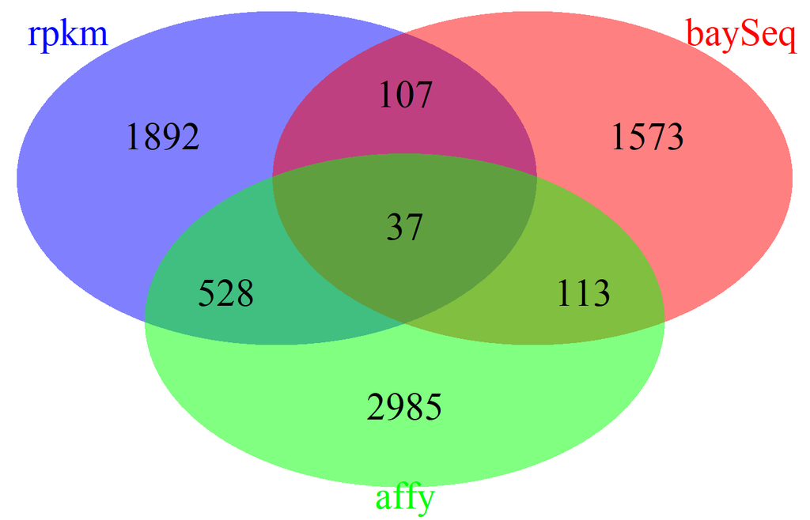

```r
VennDiagram <- draw.three.list.venndigram(
        as.vector(as.character(rnaseq_ozzy$HGNC.Approved.symbol[ which(abs(rnaseq_ozzy$Fold.Change.d6.d0) > 1.1)]))  ,
        as.vector(as.character(rnaseq_day6_0_deg$ID[which(abs(rnaseq_day6_0_FC [!is.na(as.numeric(rnaseq_day6_0_FC))]) > 2)])),
        as.vector(as.character(glist_0_6$symbol[which(abs(glist_0_6$Fold.T0vsT6) > 1.5)])),
        "rpkm", "baySeq","affy")
windows()
grid.draw(VennDiagram$figure)
```

```r
# edgeR

rnaseq_day6_0_FC <- covert.to.foldchange(rnaseq_day6_0_deg$edgeR_log2FC)

length(intersect(as.vector(as.character(rnaseq_ozzy$HGNC.Approved.symbol[ which(abs(rnaseq_ozzy$Fold.Change.d6.d0) > 1.1)])) ,
      as.vector(as.character(rnaseq_day6_0_deg$ID[which(abs(rnaseq_day6_0_FC [!is.na(as.numeric(rnaseq_day6_0_FC))]) > 2)]))))
```

```
## [1] 296
```

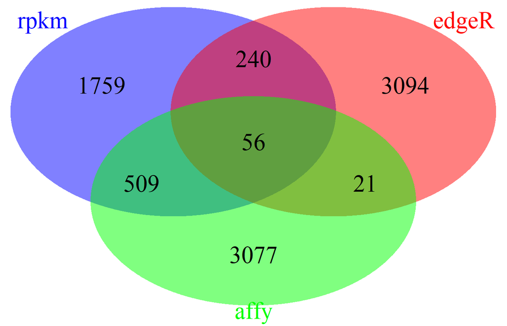

```r
VennDiagram <- draw.three.list.venndigram(
        as.vector(as.character(rnaseq_ozzy$HGNC.Approved.symbol[ which(abs(rnaseq_ozzy$Fold.Change.d6.d0) > 1.1)]))  ,
        as.vector(as.character(rnaseq_day6_0_deg$ID[which(abs(rnaseq_day6_0_FC [!is.na(as.numeric(rnaseq_day6_0_FC))]) > 2)])),
        as.vector(as.character(glist_0_6$symbol[which(abs(glist_0_6$Fold.T0vsT6) > 1.5)])),
        "rpkm", "edgeR","affy")
windows()
grid.draw(VennDiagram$figure)
```

```r
# TSPM

rnaseq_day6_0_FC <- covert.to.foldchange(rnaseq_day6_0_deg$TSPM_log2FC)

length(intersect(as.vector(as.character(rnaseq_ozzy$HGNC.Approved.symbol[ which(abs(rnaseq_ozzy$Fold.Change.d6.d0) > 1.1)])) ,
      as.vector(as.character(rnaseq_day6_0_deg$ID[which(abs(rnaseq_day6_0_FC [!is.na(as.numeric(rnaseq_day6_0_FC))]) > 2)]))))
```

```
## [1] 189
```

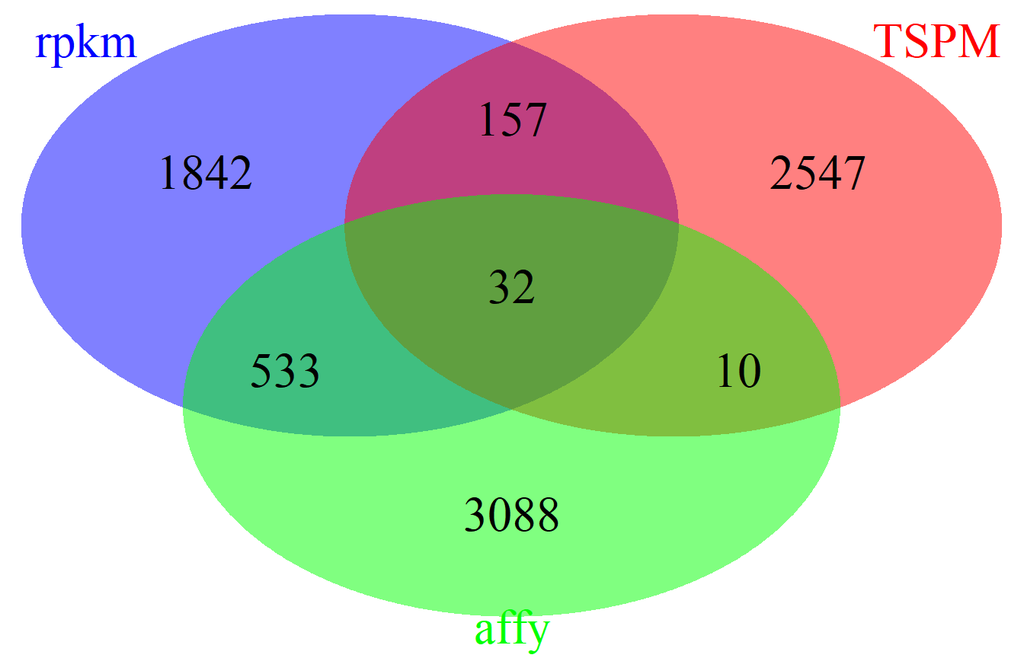

```r
VennDiagram <- draw.three.list.venndigram(
        as.vector(as.character(rnaseq_ozzy$HGNC.Approved.symbol[ which(abs(rnaseq_ozzy$Fold.Change.d6.d0) > 1.1)]))  ,
        as.vector(as.character(rnaseq_day6_0_deg$ID[which(abs(rnaseq_day6_0_FC [!is.na(as.numeric(rnaseq_day6_0_FC))]) > 2)])),
        as.vector(as.character(glist_0_6$symbol[which(abs(glist_0_6$Fold.T0vsT6) > 1.5)])),
        "rpkm", "TSPM","affy")
windows()
grid.draw(VennDiagram$figure)
```

### 4.3.3 Day9 vs. day0

```r
# DESeq

rnaseq_day9_0_FC <- covert.to.foldchange(rnaseq_day9_0_deg$DESeq_log2FC)

length(intersect(as.vector(as.character(rnaseq_ozzy$HGNC.Approved.symbol[ which(abs(rnaseq_ozzy$Fold.Change.d9.d0) > 1.1)])) ,
      as.vector(as.character(rnaseq_day9_0_deg$ID[which(abs(rnaseq_day9_0_FC [!is.na(as.numeric(rnaseq_day9_0_FC))]) > 2)]))))
```

```
## [1] 101
```

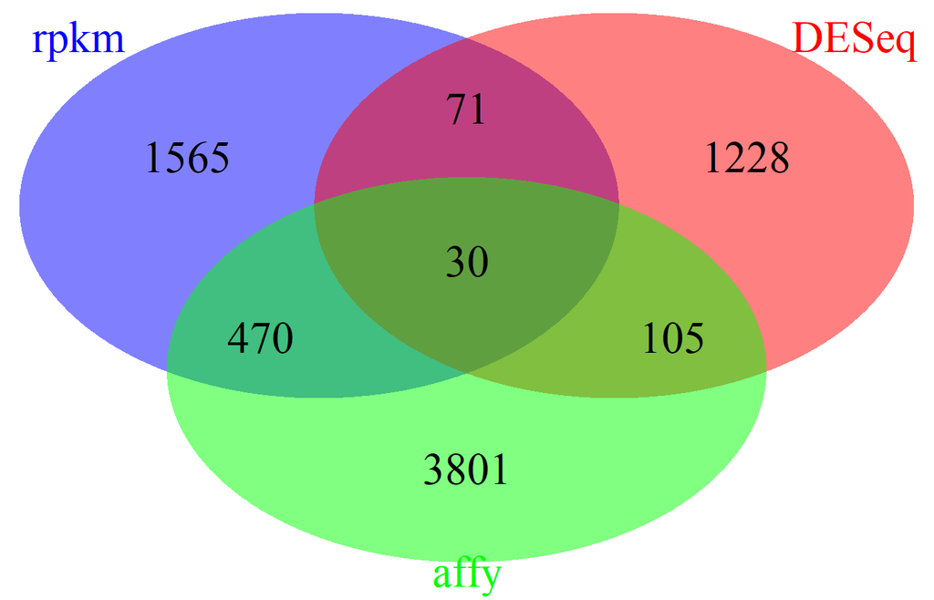

```r
VennDiagram <- draw.three.list.venndigram(
        as.vector(as.character(rnaseq_ozzy$HGNC.Approved.symbol[ which(abs(rnaseq_ozzy$Fold.Change.d9.d0) > 1.1)]))  ,
        as.vector(as.character(rnaseq_day9_0_deg$ID[which(abs(rnaseq_day9_0_FC [!is.na(as.numeric(rnaseq_day9_0_FC))]) > 2)])),
        as.vector(as.character(glist_0_9$symbol[which(abs(glist_0_9$Fold.T0vsT9) > 1.5)])),
        "rpkm", "DESeq","affy")
windows()
grid.draw(VennDiagram$figure)
```

```r
# baySeq
rnaseq_day9_0_FC <- covert.to.foldchange(rnaseq_day9_0_deg$baySeq_log2FC)

length(intersect(as.vector(as.character(rnaseq_ozzy$HGNC.Approved.symbol[ which(abs(rnaseq_ozzy$Fold.Change.d9.d0) > 1.1)])) ,
      as.vector(as.character(rnaseq_day9_0_deg$ID[which(abs(rnaseq_day9_0_FC [!is.na(as.numeric(rnaseq_day9_0_FC))]) > 2)]))))
```

```
## [1] 103
```

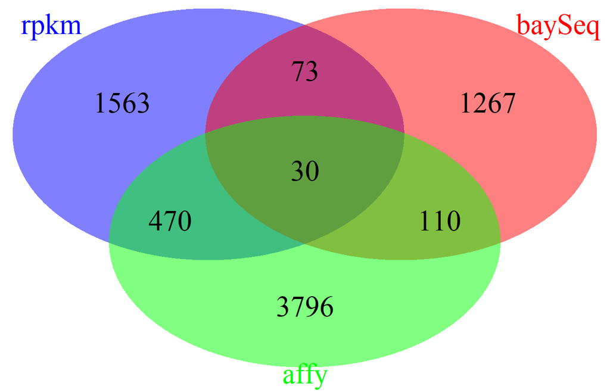

```r
VennDiagram <- draw.three.list.venndigram(
        as.vector(as.character(rnaseq_ozzy$HGNC.Approved.symbol[ which(abs(rnaseq_ozzy$Fold.Change.d9.d0) > 1.1)]))  ,
        as.vector(as.character(rnaseq_day9_0_deg$ID[which(abs(rnaseq_day9_0_FC [!is.na(as.numeric(rnaseq_day9_0_FC))]) > 2)])),
        as.vector(as.character(glist_0_9$symbol[which(abs(glist_0_9$Fold.T0vsT9) > 1.5)])),
        "rpkm", "baySeq","affy")
windows()
grid.draw(VennDiagram$figure)
```

```r
# edgeR

rnaseq_day9_0_FC <- covert.to.foldchange(rnaseq_day9_0_deg$edgeR_log2FC)

length(intersect(as.vector(as.character(rnaseq_ozzy$HGNC.Approved.symbol[ which(abs(rnaseq_ozzy$Fold.Change.d9.d0) > 1.1)])) ,
      as.vector(as.character(rnaseq_day9_0_deg$ID[which(abs(rnaseq_day9_0_FC [!is.na(as.numeric(rnaseq_day9_0_FC))]) > 2)]))))
```

```
## [1] 167
```

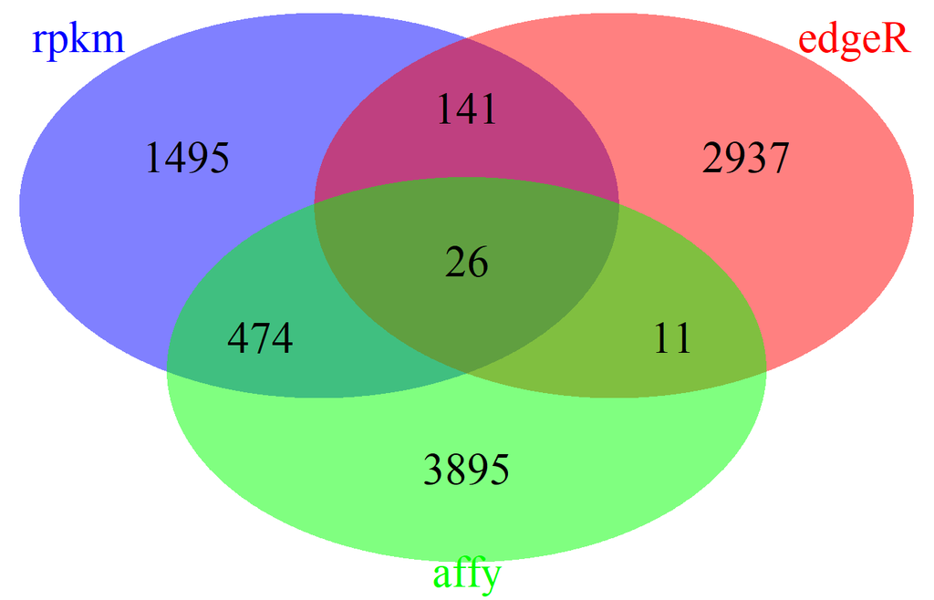

```r
VennDiagram <- draw.three.list.venndigram(
        as.vector(as.character(rnaseq_ozzy$HGNC.Approved.symbol[ which(abs(rnaseq_ozzy$Fold.Change.d9.d0) > 1.1)]))  ,
        as.vector(as.character(rnaseq_day9_0_deg$ID[which(abs(rnaseq_day9_0_FC [!is.na(as.numeric(rnaseq_day9_0_FC))]) > 2)])),
        as.vector(as.character(glist_0_9$symbol[which(abs(glist_0_9$Fold.T0vsT9) > 1.5)])),
        "rpkm", "edgeR","affy")
windows()
grid.draw(VennDiagram$figure)
```

```r
# TSPM

rnaseq_day9_0_FC <- covert.to.foldchange(rnaseq_day9_0_deg$TSPM_log2FC)

length(intersect(as.vector(as.character(rnaseq_ozzy$HGNC.Approved.symbol[ which(abs(rnaseq_ozzy$Fold.Change.d9.d0) > 1.1)])) ,
      as.vector(as.character(rnaseq_day9_0_deg$ID[which(abs(rnaseq_day9_0_FC [!is.na(as.numeric(rnaseq_day9_0_FC))]) > 2)]))))
```

```
## [1] 147
```

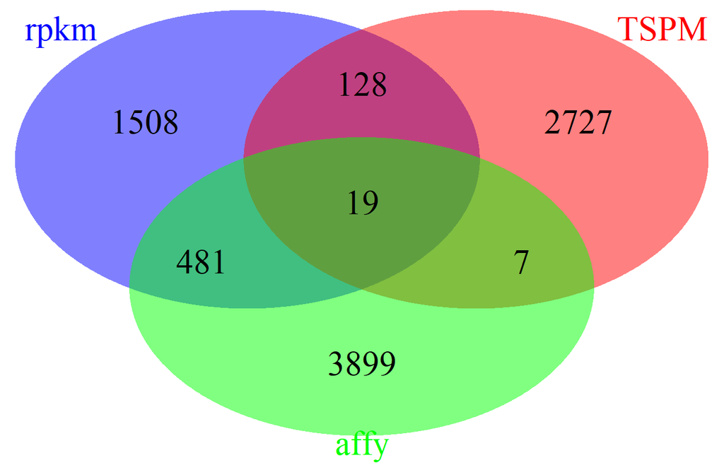

```r
VennDiagram <- draw.three.list.venndigram(
        as.vector(as.character(rnaseq_ozzy$HGNC.Approved.symbol[ which(abs(rnaseq_ozzy$Fold.Change.d9.d0) > 1.1)]))  ,
        as.vector(as.character(rnaseq_day9_0_deg$ID[which(abs(rnaseq_day9_0_FC [!is.na(as.numeric(rnaseq_day9_0_FC))]) > 2)])),
        as.vector(as.character(glist_0_9$symbol[which(abs(glist_0_9$Fold.T0vsT9) > 1.5)])),
        "rpkm", "TSPM","affy")
windows()
grid.draw(VennDiagram$figure)
```

# 5 Conclusion

There were minimum overlap between RNAseq and microarray experiment. Alternatively, the scientists (Janine) proposed to see whether the pathway or downstream pathway would have more overlap.